# Derivation of Stochastic Posterior Criterion

2025-12-27

# 1 1. Latent evidence and posterior

Assume the true state of the world on a trial is $D \in \{-1,+1\}$ (direction of moving dots (left or right)), and the agent observes a latent, noisy evidence of this called $e$. $\mu$ represents the signal strength i.e. coherence (percentage of dots moving coherently towards D, in a Random dot Motion task) and is strictly positive, as the direction comes from D.

If we assume, as Signal detection theory, that the evidence is Gaussian, we can write:

$$e \sim \mathcal{N}(D \cdot \mu, \sigma)$$

We now assume that the agent computes the posterior probability of D given the evidence he collected. This means that for the case where D = 1 we have from bayes theorm that:

$$P(D=1 \mid e) = \frac{P(e \mid D=1) \cdot P(D=1)}{P(e \mid D=1) \cdot
P(D=1) + P(e \mid D=-1) \cdot P(D=-1)}$$
where the prior probability of e is written as; $p(e) = P(e \mid D=1) \cdot P(D=1) + P(e \mid D=-1) \cdot P(D=-1)$ due to the law of total probability.

This means that the posterior probability that the state of the world is 1 (dots moving right) given the evidence is just the likelihood of the evidence given that the state was 1 weighted by the prior of the stimulus, divided by the total probability.

If we now assume that the prior of the true state of the world is flat (i.e. `P(D = 1)` = `P(D = -1)` = 0.5). we have:

$$P(D=1 \mid e) = \frac{P(e \mid D=1)}{P(e \mid D=1) + P(e \mid D=-1)}$$

Plugging in the Gaussian distributions from the assumption of the evidence:

$$e \mid D=1 \sim \mathcal{N}(\mu, \sigma^2), \quad
e \mid D=-1 \sim \mathcal{N}(-\mu, \sigma^2)$$

Then the likelihoods are:

$$P(e \mid D=1) = \frac{1}{\sqrt{2\pi\sigma^2}} \exp\Big(-\frac{(e -
\mu)^2}{2\sigma^2}\Big), \quad
P(e \mid D=-1) = \frac{1}{\sqrt{2\pi\sigma^2}} \exp\Big(-\frac{(e +
\mu)^2}{2\sigma^2}\Big)$$

Plugging these into the posterior formula:

$$\begin{aligned}
P(D=1 \mid e) &= \frac{\exp\Big(-\frac{(e -
\mu)^2}{2\sigma^2}\Big)}{\exp\Big(-\frac{(e - \mu)^2}{2\sigma^2}\Big) +
\exp\Big(-\frac{(e + \mu)^2}{2\sigma^2}\Big)}
\end{aligned}$$

Now if one factors out the $\exp\Big(-\frac{(e - \mu)^2}{2\sigma^2}\Big)$ term from the numerator we get:

$$P(D=1 \mid e) = \frac{1}{1 + \exp\Big(\frac{(e + \mu)^2 - (e -
\mu)^2}{2\sigma^2}\Big)}$$
writing out the sqaures $(e + \mu)^2 = e^2 + \mu^2 + 2\cdot e \cdot \mu$ & $(e - \mu)^2 = e^2 + \mu^2 - 2\cdot e \cdot \mu$, we end up with:

$$P(D=1 \mid e) = \frac{1}{1 + \exp\Big(-\frac{2 \cdot e \cdot
\mu}{\sigma^2}\Big)}$$
This type of fraction is exactly the inverse logit transformation $g(.) = \frac{1}{1+exp(-x)}$, which means:
$$P(D=1 \mid e) = g\Big(\frac{2 \cdot e \cdot \mu}{\sigma^2}\Big)$$
From this one can get to the usual optimal policy of responding 1, i.e. when the probability of the true state of the world given the evidence is above 0.5 and otherwise respond -1

# 2 Decision Policy

## 2.1 1. On the probability scale:

From this posterior, the **optimal policy** is:

$$a =
\begin{cases}
1 & \text{if } P(D=1 \mid e) > 0.5 \\
-1 & \text{otherwise}
\end{cases}$$

Equivalently, since the sigmoid crosses 0.5 at 0, i.e. $g(0) = 0.5$, the only thing in the function that changes the sign is the evidence we get:

$$a =
\begin{cases}
1 & \text{if } \frac{2 e \mu}{\sigma^2} > 0 \\
-1 & \text{if } \frac{2 e \mu}{\sigma^2} \le 0
\end{cases}
\quad \Longleftrightarrow \quad
a =
\begin{cases}
1 & \text{if } e > 0 \\
-1 & \text{if } e \le 0
\end{cases}$$

What this parameterization does allow is to say that the decision criterion (policy) is not on the latent evidence scale but on the probability scale. so we might introduce a different non-strict policy on the probability scale. given that the citerion needs to be bounded on $[0 , 1]$ the maximum entropy distribution must be the beta distribution:

$$c \sim \text{Beta}(\alpha, \beta)$$

So the idea is that on each trial a new citerion, c, is drawn (This is because the agent does not deterministically respond 1 or 0 given a particular probability of the true state of the world, thus this introduces “decision noise”, which is placed on the posterior probability instead of on the stimulus axis.

$$a =
\begin{cases}
1 & \text{if } P(D=1 \mid e) > c \\
-1 & \text{otherwise}
\end{cases}$$

$$a =
\begin{cases}
1 & \text{if } c < P(D=1 \mid e)\\
-1 & \text{otherwise}
\end{cases}$$

This can then be written as:

$$P(a = 1 | e) = P(c < P(D=1 \mid e))$$
as the probability distribution of c was given by $c \sim \text{Beta}(\alpha, \beta)$ this amounts to the cumulative beta distribution:

If this then is parameterized as a mean and precision beta distribution one can think of $\alpha$ as the decision bias with 0.5 being no bias (optimal policy) and $\beta$ being the precision of decision noise.

## 2.2 2. On the Evidence Scale

Alternatively, place decision noise **directly on the evidence**:

$$k \sim \mathcal{N}(\mu_k, \sigma_k^2)$$

Decision policy:

$$a =
\begin{cases}
1 & \text{if } e > k \\
-1 & \text{otherwise}
\end{cases}$$

Then the probability of choosing 1 is:

$$P(a = 1 \mid e) = P(k < e)$$

Since k follows a normal distribution: $(k \sim \mathcal{N}(\mu_k, \sigma_k^2)$, we can calculate the above probability statement as:

$$P(a = 1 \mid e) = \Phi\!\left(\frac{e - \mu_k}{\sigma_k}\right)$$

where $\Phi(\cdot)$ denotes the standard normal cumulative distribution function.

# 3 Response times

## 3.1 1. Absolute evidence

Now this decision does not come in a vacuum, but is accompanied by a response time (RT). This RT we assume is a function of the evidence, in such a way that stronger evidence will give faster responses i.e. easier trials will be faster. Further we posit that RT will have a lower bound that will be governed by a non-decision-time $RT_{ndt}$. This gives us that:
$$RT \sim RT_{ndt} + f(|e|)$$
here stronger evidence is given by the absolute value of the evidence. We might then also assume that the noise is log normally distributed in order to also withhold that RT’s are strictly positive:
$$RT \sim log(\mathcal{N}(f(|e|), RT_\sigma) + RT_{ndt}$$

# 4 Simulations:

## 4.1 parameters

```r
pacman::p_load(tidyverse,posterior,bayesplot,cmdstanr)

set.seed(199742)

# -----------------------------
# Set parameters
# -----------------------------
n_trials <- 500        # number of trials
sigma_e <- 1           # noise on evidence (needs to be fixed for now)

mu_beta <- 0.5               # criterion mean for the beta distribution
prec_beta <- 3             # criterion precision for the beta distribution

mu_k <- 0                  # criterion mean on the evidence scale (gaussian distribution)
sigma_k <- 1                 # criterion sd on the evidence scale (gaussian distribution)

rt_ndt = 0.2          # non decision time for RT
rt_sigma = 0.5        # Residual variance of RT
rt_e = 0.4            # scaling of the mean RT given evidence.
```

## 4.2 Trial by trial level experimental parameters:

```r
# Coherence level (stimulus intensity)
X <- abs(rnorm(n_trials,1,1))

# stimuli (left or right)
D <- sample(c(-1, 1), n_trials, replace = TRUE)  # true stimulus

# Simulate evidence
e <- rnorm(n_trials, mean = D * X, sd = sigma_e)

# Compute posterior P(D=1|e)
p_D1 <- 1 / (1 + exp(-2 * X * e / sigma_e^2))

# Posterior-based stochastic policy (using the beta distribution to set citeria)
c_beta <- extraDistr::rprop(n_trials,prec_beta,mu_beta)           # random threshold
a_beta <- ifelse(p_D1 > c_beta, 1, -1)         # choices

# Evidence-based stochastic policy (guassian distribution for citera)
k_gauss <- rnorm(n_trials, mu_k, sigma_k)          # citerion on trial t
p_gauss = pnorm((e-mu_k)/sigma_k)                  #  probability of response on trial t given the citerion
a_gauss = rbinom(n_trials,1,p_gauss)               # binary response

# Dataframe
df <- data.frame(
  e = e,
  D = D,
  X =X,
  rt = rlnorm(n_trials,rt_e * -abs(e),rt_sigma) + rt_ndt,
  rt2 = rlnorm(n_trials,-abs(p_D1-0.5),rt_sigma) - rt_ndt,
  a_beta = a_beta,
  a_gauss = a_gauss
)
```

# 5 Plot simulation:

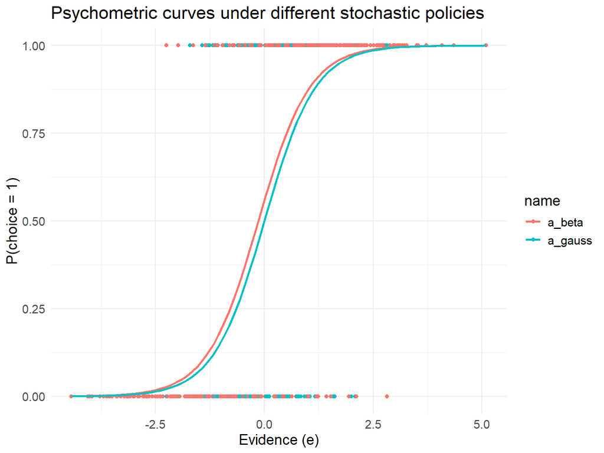

```r
df %>% pivot_longer(cols = c("a_gauss","a_beta")) %>% mutate(value = ifelse(value < 0, 0, value)) %>%
  ggplot(aes(x = e, y = value, col = name)) +
  geom_point()+
  geom_smooth(method = "glm",
              method.args = list(family = "binomial"),
              se = FALSE)+
  labs(x = "Evidence (e)", y = "P(choice = 1)",
       title = "Psychometric curves under different stochastic policies") +
  theme_minimal() +
  theme(text = element_text(size = 14))
```

[figure not shown]

```r
df %>%
  ggplot(aes(x = e, y = rt)) +
  geom_point()+
  labs(x = "Evidence (e)", y = "P(choice = 1)",
       title = "Response times") +
  theme_minimal() +
  theme(text = element_text(size = 14))
```

# 6 Fit model

```r
mod = cmdstanr::cmdstan_model(here::here("Derivations","test.stan"))

datastan = list(a = df$a_gauss,
                RT = df$rt,
                D = df$D,
                N = nrow(df),
                X = df$X)


fit = mod$sample(data = datastan,
                 iter_warmup = 500,
                 refresh = 0,
                 iter_sampling = 500,
           parallel_chains = 4)
```

```
## Running MCMC with 4 parallel chains...
```

```
## Chain 1 finished in 6.8 seconds.
## Chain 2 finished in 6.7 seconds.
## Chain 3 finished in 7.2 seconds.
## Chain 4 finished in 7.9 seconds.
##
## All 4 chains finished successfully.
## Mean chain execution time: 7.1 seconds.
## Total execution time: 8.4 seconds.
```

# 7 Output:

```r
fit$summary(c("RT_e","sigma_choice","sigma_rt","mean_choice","RT_ndt"))
```

| variable | mean | median | sd | mad | q5 | q95 | rhat | ess_bulk | ess_tail |
| --- | --- | --- | --- | --- | --- | --- | --- | --- | --- |
| RT_e | 0.42562204 | 0.42874850 | 0.04006347 | 0.04049574 | 0.3569259 | 0.4884213 | 1.002378 | 449.8773 | 734.7674 |
| sigma_choice | 1.06437795 | 1.05650000 | 0.15844272 | 0.15621415 | 0.8185407 | 1.3454490 | 1.013554 | 403.5230 | 842.0218 |
| sigma_rt | 0.51722540 | 0.51652300 | 0.02717584 | 0.02687287 | 0.4723769 | 0.5636758 | 1.005284 | 858.1297 | 1238.9454 |
| mean_choice | -0.03375685 | -0.03206335 | 0.09096703 | 0.09117189 | -0.1839042 | 0.1153923 | 1.005044 | 1339.5836 | 1350.6615 |
| RT_ndt | 0.22518272 | 0.22887250 | 0.02104381 | 0.01974675 | 0.1865304 | 0.2535360 | 1.003232 | 545.0065 | 634.4780 |

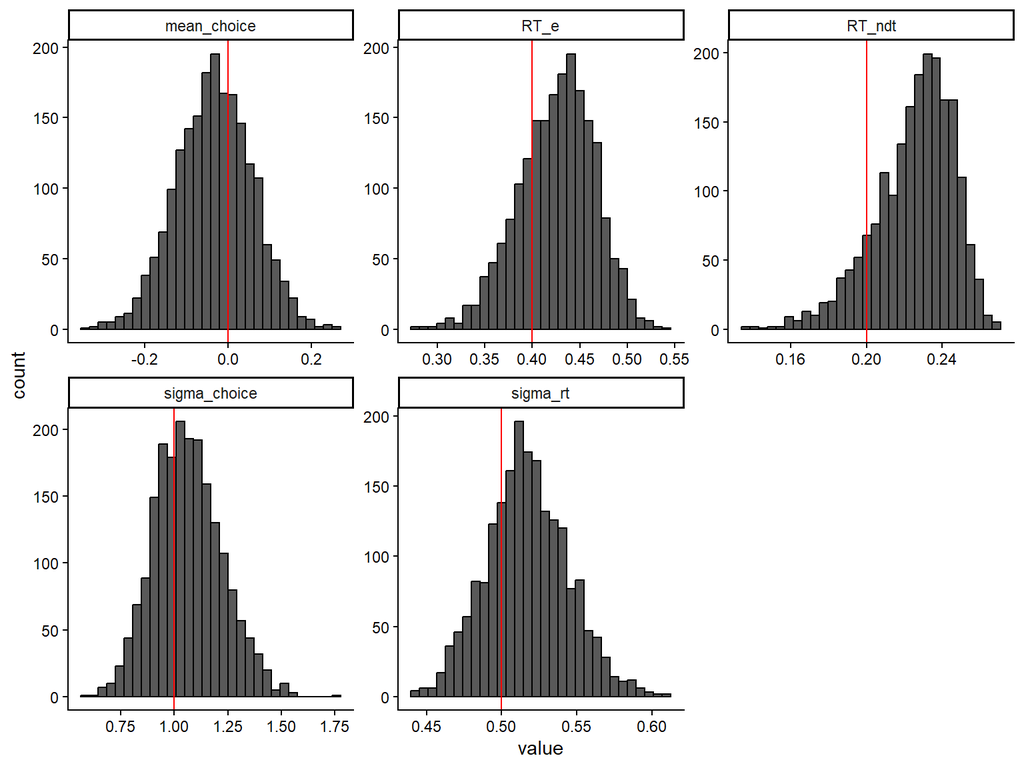

```r
as_draws_df(fit$draws(c("RT_e","sigma_choice","sigma_rt","RT_ndt","mean_choice"))) %>% select(-contains(".")) %>%
  pivot_longer(everything()) %>%
  mutate(simulated = ifelse(name == "RT_e",rt_e,ifelse(name == "sigma_choice",sigma_k,
                                                       ifelse(name == "sigma_rt",rt_sigma,ifelse(name == "RT_ndt",rt_ndt,mu_k))))) %>%
  ggplot(aes(x = value))+
  geom_histogram(col = "black")+geom_vline(aes(xintercept = simulated), col = "red")+facet_wrap(~name, scales = "free")+theme_classic()
```

## 7.1 posterior distributions and lines = simulated values

## 7.2 simulated evidence vs estimated:

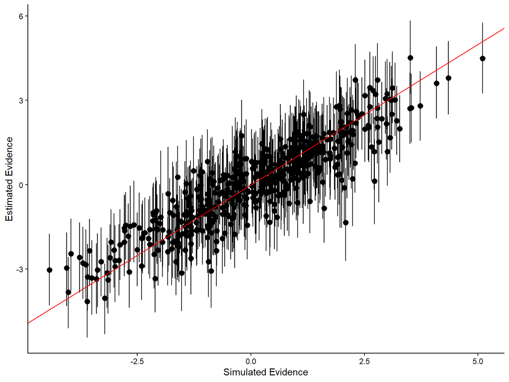

```r
data.frame(fit$summary("evidence")) %>% mutate(simulated = df$e) %>%
  ggplot(aes(x = simulated, y = mean, ymin = q5, ymax = q95))+
  geom_pointrange()+theme_classic()+geom_abline(col = "red")+
  xlab("Simulated Evidence")+
  ylab("Estimated Evidence")
```